# Homework_2

Sandile Nhlalo-Sibanda

2022-04-07

# BREAKING BAD

## Question 1: A brief description of the show (use *italics* for names).

Set in *Albuquerque*, *New Mexico*, between 2008 and 2010, *Breaking Bad* follows *Walter White*, a meek high school chemistry teacher who transforms into a ruthless player in the local methamphetamine drug trade, driven by a desire to financially provide for his family after being diagnosed with terminal lung cancer. Initially making only small batches of meth with his former student *Jesse Pinkman* in a rolling meth lab, *Walter* and *Jesse* eventually expand to make larger batches of a special blue meth that is incredibly pure and creates high demand. Walter takes on the name “Heisenberg” to mask his identity. Because of his drug-related activities, *Walter* eventually finds himself at odds with his family, the *Drug Enforcement Administration* (DEA) through his brother-in-law *Hank Schrader*, the local gangs, and the *Mexican* drug cartels (including their regional distributors), putting him and his family’s lives at risk.

## Question 2: A photo with the logo or a shot from the show itself.

[figure not shown]

Breaking Bad Cover

##Question 3: A summary of some basic statistics (e.g. on viewership or ratings).

| Season | Timeslot (ET) | Episodes | First aired |  | Last aired |  | TV season | Avg. viewers (millions) |  |  |
| --- | --- | --- | --- | --- | --- | --- | --- | --- | --- | --- |
|  |  |  | Date | Viewers (millions) | Date | Viewers (millions) |  |  |  |  |
| 1 | Sunday 10:00 pm | 7 | January 20, 2008 | 1.41<sup>[163]</sup> | March 9, 2008 | 1.50<sup>[164]</sup> |  |  | 2007–08 | 1.23<sup>[165]</sup> |
| 2 |  | 13 | March 8, 2009 | 1.66<sup>[166]</sup> | May 31, 2009 | 1.50<sup>[167]</sup> | 2008–09 | 1.30<sup>[168]</sup> |  |  |
| 3 |  | 13 | March 21, 2010 | 1.95<sup>[169]</sup> | June 13, 2010 | 1.56<sup>[170]</sup> | 2009–10 | 1.52<sup>[171]</sup> |  |  |
| 4 |  | 13 | July 17, 2011 | 2.58<sup>[172]</sup> | October 9, 2011 | 1.90<sup>[173]</sup> | 2010–11 | 1.87<sup>[174]</sup> |  |  |
| 5A |  | 8 | July 15, 2012 | 2.93<sup>[175]</sup> | September 2, 2012 | 2.78<sup>[176]</sup> | 2011–12 | 4.32<sup>[177]</sup> |  |  |
| 5B | Sunday 9:00 pm | 8 | August 11, 2013 | 5.92<sup>[178]</sup> | September 29, 2013 | 10.28<sup>[179]</sup> | 2012–13 |  |  |  |

## Question 4: A graph of the viewership over time.

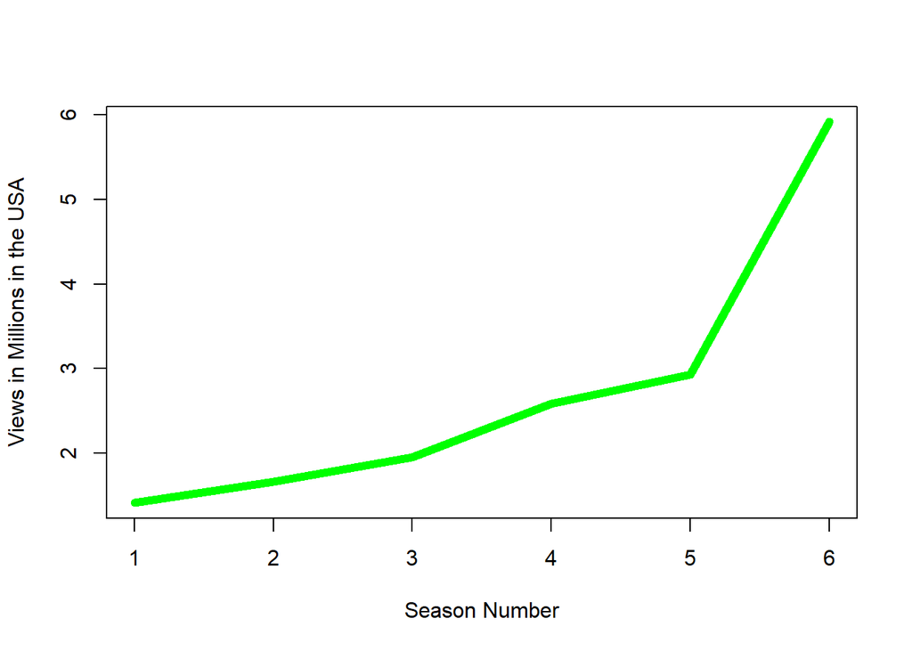

## Question 5: A graph of the episode-to-episode (or season-to-season) changes in viewership.

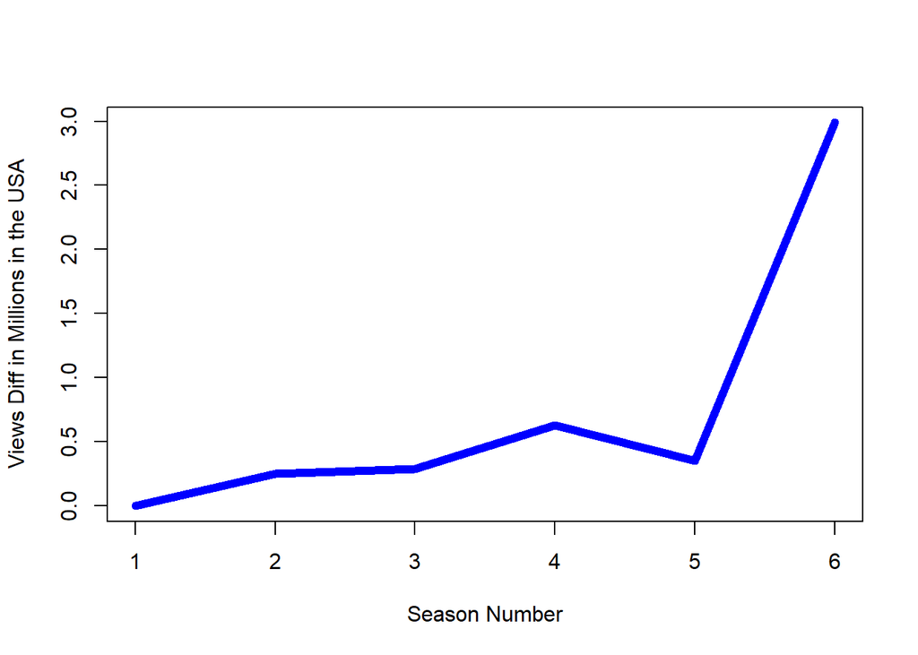

## Question 6: A short description of the observed changes that includes inline references to numbers (e.g. the viewership decreased by `insert_calculated_number` between seasons 3 and 5).

Between the 1st season and the 2nd season, we observe an increase of 0.25. Between the 2nd season and the 3rd season, we observe an increase of 0.29. Between the 3rd season and the 4th season, we observe an increase of 0.63. Between the 4th season and the 5th season, we observe an increase of 0.35. Between the 5th season and the 6th season, we observe a drastic increase of 2.99.